# IMDb Video Games Data Analysis

Larry Nguyen

2022-09-20

## Introduction

Thank you for viewing my personal project. This project is still ongoing as I am exploring different ways to visualize and display data to a general audience. This project is programmed in R and the following packages are used: ggplot2, rmarkdown. The data set from this project was gathered from IMDb and collectively published on Kaggle by Muhammad Adil Talay. For more information on the data set, visit https://www.kaggle.com/datasets/muhammadadiltalay/imdb-video-games. The following questions I am currently exploring are: What is the average rating for each video game genre? What is the most popular video game in each genre? With no further ado, let’s begin by analyzing our first game genre—Action.

## Action Video Games

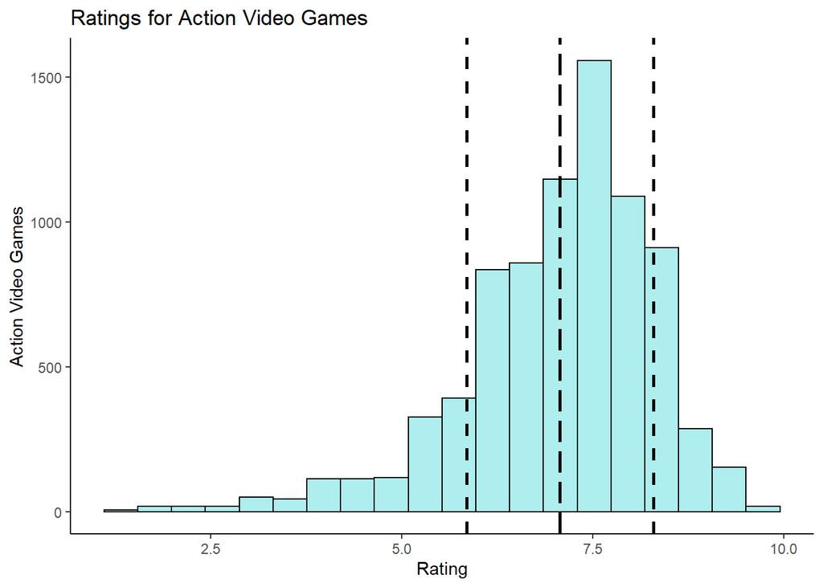

Figure 1: Histogram distribution of IMDb ratings for action video games. Ratings range from 0 (min) to 10 (max). The long dashes represent the mean, while the short dashes represent +1 and -1 standard deviation of the mean.

There are 11930 action games. The distribution of ratings for action games is left skewed with an average rating of 7.07 and a standard deviation of 1.22. The most popular action video game(s) by rating is/are Red Dead Redemption II, The Last of Us, Uncharted 2: Among Thieves, God of War III, Shadow the Hedgehog, Chrono Trigger+, Gundam Area Wars, Another Century’s Episode, DoubleShake, DX-Ball, Fast and Furious: Super Cars.

## Adventure Video Games

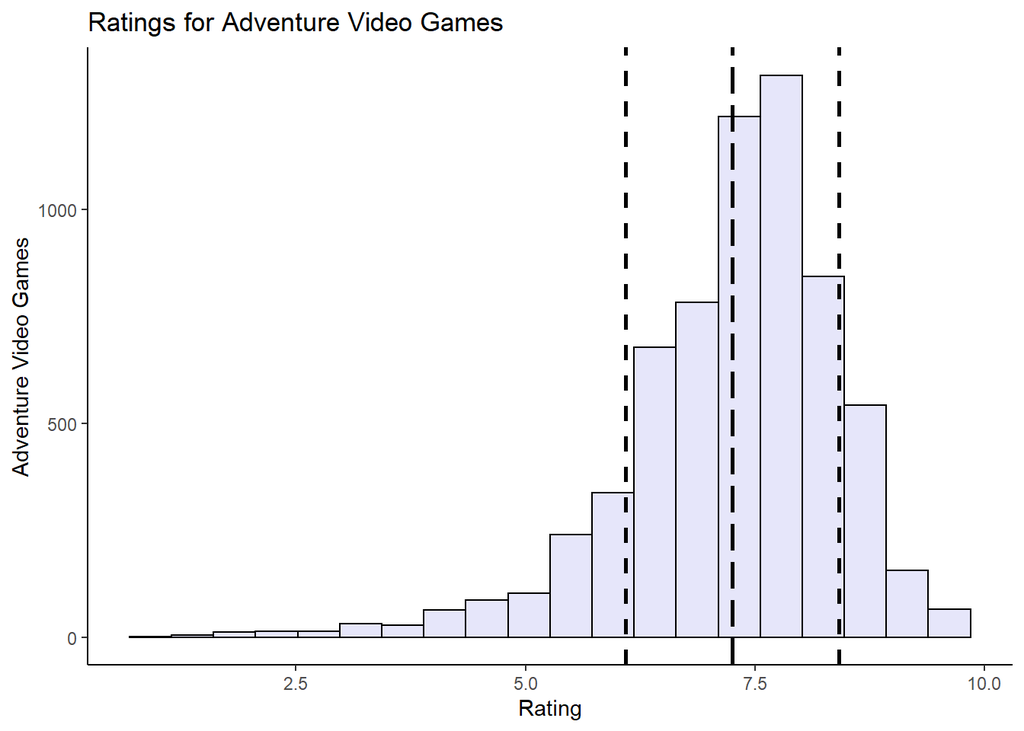

Figure 2: Histogram distribution of IMDb ratings for adventure video games. Ratings range from 0 (min) to 10 (max). The long dashes represent the mean, while the short dashes represent +1 and -1 standard deviation of the mean.

There are 10334 adventure games. The distribution of ratings for adventure games is left skewed with an average rating of 7.25 and a standard deviation of 1.16. The most popular adventure video game(s) by rating is/are Red Dead Redemption II, Horizon Forbidden West, Xenoblade Chronicles 3, Metal Gear Solid V: The Phantom Pain, Command & Conquer: Red Alert 3 - Uprising, Terrorist Takedown: War in Colombia, Lady Sia, Railfan: Taiwan High Speed Rail, Silhouette Mirage, Ratchet & Clank: Before the Nexus, S.P.Y.: Special Project Y..

## Comedy Video Games

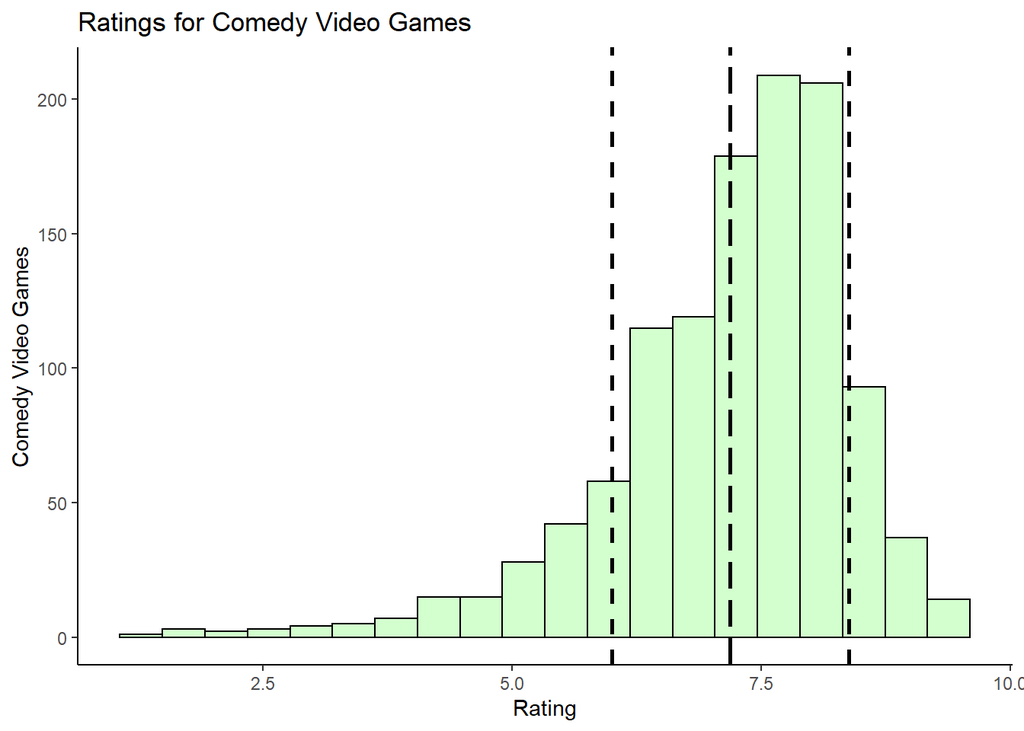

Figure 3: Histogram distribution of IMDb ratings for comedy video games. Ratings range from 0 (min) to 10 (max). The long dashes represent the mean, while the short dashes represent +1 and -1 standard deviation of the mean.

There are 1783 comedy games. The distribution of ratings for comedy games is left skewed with an average rating of 7.19 and a standard deviation of 1.19. The most popular comedy video game(s) by rating is/are Bayonetta 2, The Lord of the Rings: War in the North, Over the Hedge.

## Crime Video Games

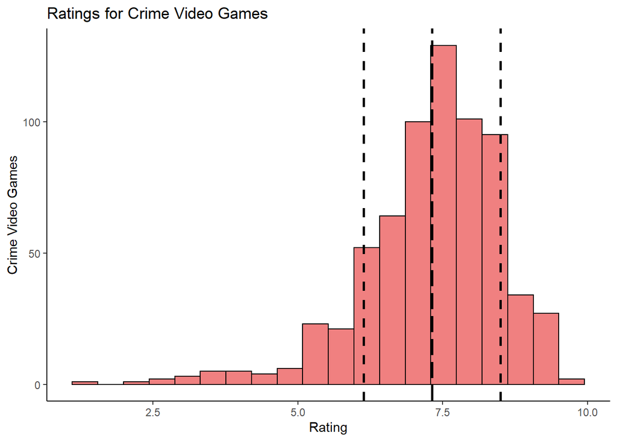

Figure 4: Histogram distribution of IMDb ratings for crime video games. Ratings range from 0 (min) to 10 (max). The long dashes represent the mean, while the short dashes represent +1 and -1 standard deviation of the mean.

There are 895 crime games. The distribution of ratings for crime games is left skewed with an average rating of 7.32 and a standard deviation of 1.18. The most popular crime video game(s) by rating is/are Spider-Man, Hunt Down the Freeman.

## Family Video Games

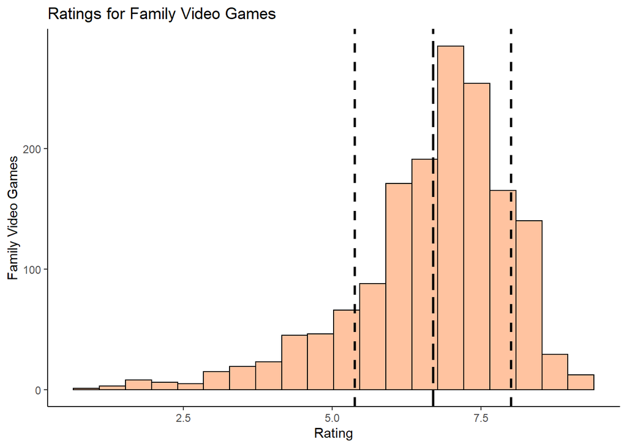

Figure 5: Histogram distribution of IMDb ratings for family video games. Ratings range from 0 (min) to 10 (max). The long dashes represent the mean, while the short dashes represent +1 and -1 standard deviation of the mean.

There are 2875 family games. The distribution of ratings for family games is left skewed with an average rating of 6.69 and a standard deviation of 1.31. The most popular family video game(s) by rating is/are God of War, Lego Star Wars: The Skywalker Saga, Control, Assassin’s Creed: Brotherhood.

## Fantasy Video Games

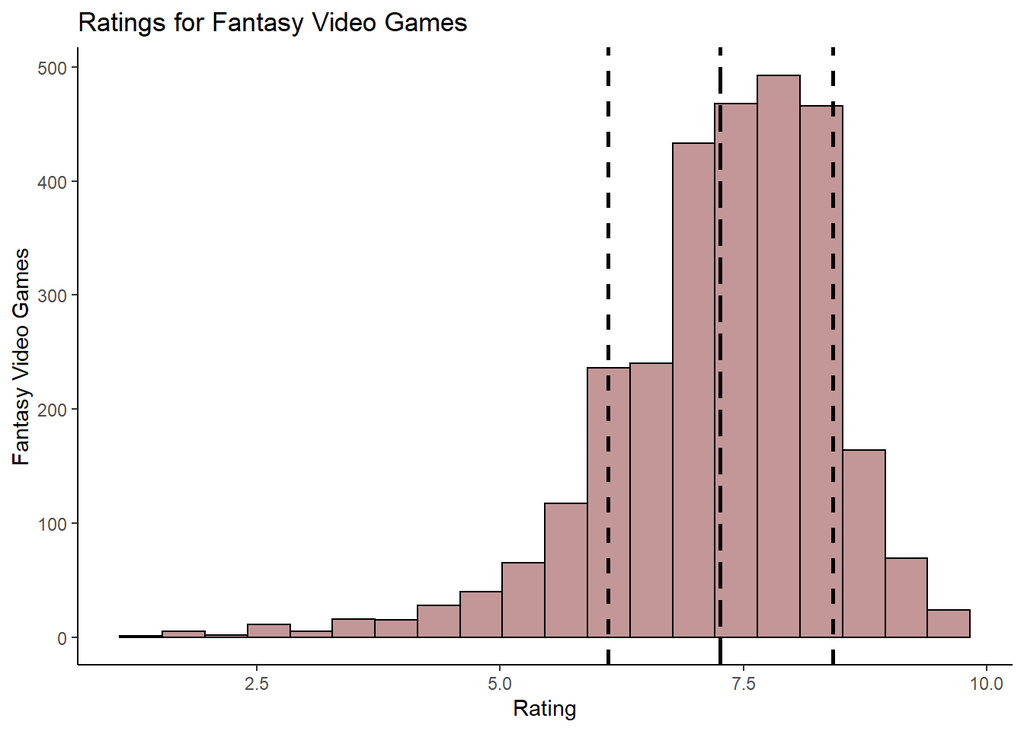

Figure 6: Histogram distribution of IMDb ratings for fantasy video games. Ratings range from 0 (min) to 10 (max). The long dashes represent the mean, while the short dashes represent +1 and -1 standard deviation of the mean.

There are 4350 fantasy games. The distribution of ratings for fantasy games is left skewed with an average rating of 7.26 and a standard deviation of 1.15. The most popular fantasy video game(s) by rating is/are Fortnite, Mass Effect 2, Jurassic Park Arcade.

## Mystery Video Games

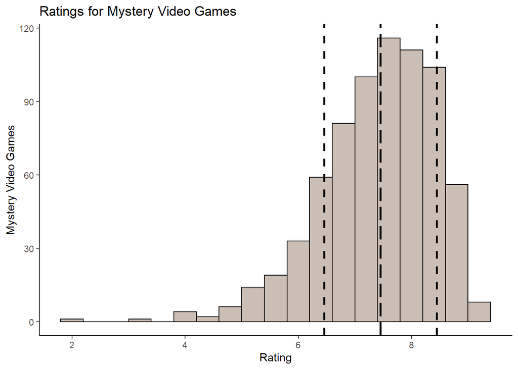

Figure 7: Histogram distribution of IMDb ratings for mystery video games. Ratings range from 0 (min) to 10 (max). The long dashes represent the mean, while the short dashes represent +1 and -1 standard deviation of the mean.

There are 1185 mystery games. The distribution of ratings for mystery games is left skewed with an average rating of 7.45 and a standard deviation of 1. The most popular mystery video game(s) by rating is/are Castlevania: Lords of Shadow, Plants vs. Zombies.

## Sci-Fi Video Games

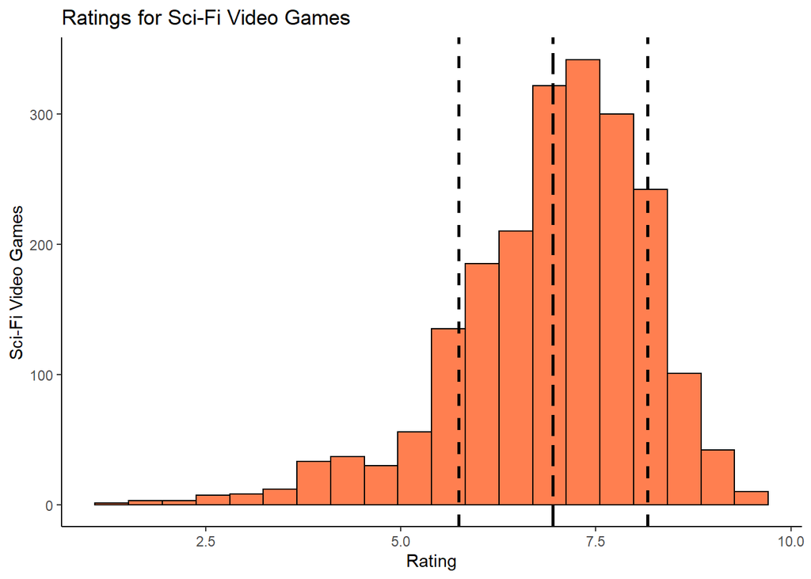

Figure 8: Histogram distribution of IMDb ratings for sci-fi video games. Ratings range from 0 (min) to 10 (max). The long dashes represent the mean, while the short dashes represent +1 and -1 standard deviation of the mean.

## Thriller Video Games

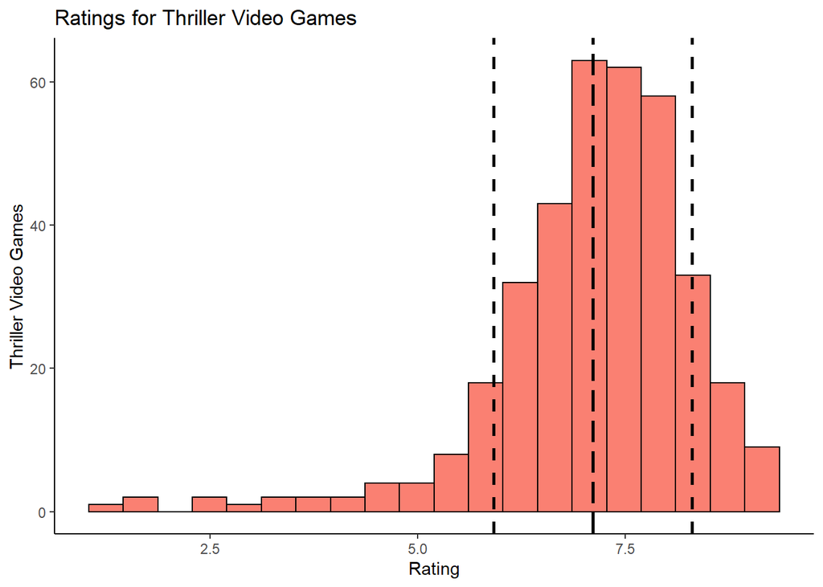

Figure 9: Histogram distribution of IMDb ratings for thriller video games. Ratings range from 0 (min) to 10 (max). The long dashes represent the mean, while the short dashes represent +1 and -1 standard deviation of the mean.

There are 523 thriller games. The distribution of ratings for thriller games is left skewed with an average rating of 7.11 and a standard deviation of 1.2. The most popular thriller video game(s) by rating is/are Cyberpunk 2077, God of War: Ghost of Sparta, ARK: Survival Evolved.